# TOUCH-BRAIN: Pre-Registration Plan

Phuc TU Nguyen

2025-06-06

Behavioral and EEG data are merged across all participants and blocks. Block number and trial number are assigned per condition (t/m × a/p × unimodal/both)

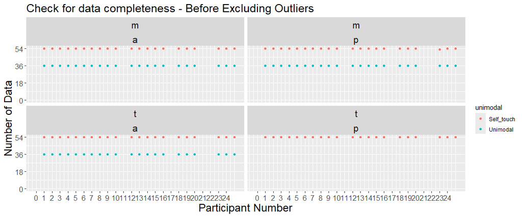

## 1.1 Load and preprocess raw data

**Target Length**: based on the task type (touchLength or movLength is selected).

**Condition Labels (condN)**: (1) Self-touch Active - Judge Touch, (2) Self-touch Passive - Judge Touch, (3) Self-touch Active - Judge Move, (4) Self-touch Passive - Judge Move*, (5) Unimodal - Judge Touch, (6) Unimodal Active - Judge Move, (7) Unimodal Passive - Judge Move.

**Flipped Gain**: Calculated as $|\frac{TargetLength}{InterferenceLength}\ |$.

**Absolute Error**: Calculated as $|\frac{ReportedLength}{TargetLength}\ - 1|$.

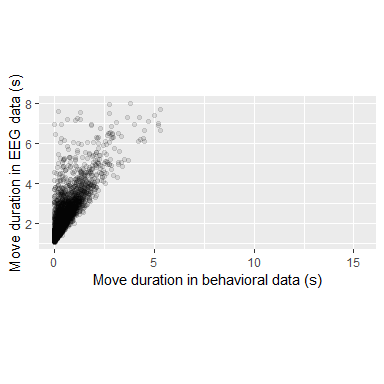

| sbjN | condN | BLOCK | trialN | flipped.gain | Target_length | resp | C3_pre | C3_full | C3_early | C3_late | C4_pre | C4_full | C4_early | C4_late |
| --- | --- | --- | --- | --- | --- | --- | --- | --- | --- | --- | --- | --- | --- | --- |
| P01 | 1.Touch_Active | 1 | 0 | 2.NonUnity | 6 | 4.400 | 1.9278330 | 3.4505866 | 1.82592952 | 3.4832940 | 1.702322e+00 | 4.3892522 | 2.30887461 | 4.4676638 |
| P01 | 1.Touch_Active | 1 | 1 | 2.NonUnity | 8 | 8.050 | 3.5537989 | 1.9922717 | 4.05846024 | 1.6067100 | 3.215884e+00 | 2.0960815 | 2.38758039 | 1.8108578 |
| P01 | 1.Touch_Active | 1 | 2 | 2.NonUnity | 4 | 3.775 | 3.4616473 | 2.4481795 | 2.26849604 | 2.6155183 | 2.528124e+00 | 2.8160000 | 2.34875321 | 2.9391079 |
| P01 | 1.Touch_Active | 1 | 3 | 2.NonUnity | 8 | 9.250 | 2.4935069 | 2.3732514 | 3.82159948 | 1.6001028 | 2.921044e+00 | 2.3166444 | 3.06200886 | 1.8702554 |
| P01 | 1.Touch_Active | 1 | 4 | 2.NonUnity | 6 | 8.225 | 1.6842633 | 2.1899462 | 2.04415941 | 2.2529428 | 2.175063e+00 | 2.6068962 | 1.80195963 | 2.9358530 |
| P01 | 1.Touch_Active | 1 | 5 | 2.NonUnity | 8 | 6.500 | 3.3136733 | 2.7990255 | 8.31131172 | 2.3131981 | 5.501198e+00 | 2.6795096 | 5.97077990 | 2.2820828 |
| P01 | 1.Touch_Active | 1 | 6 | 2.NonUnity | 6 | 4.425 | 2.4173443 | 1.8550768 | 2.85232353 | 1.8036387 | 2.643717e+00 | 2.5924988 | 2.68512368 | 2.6597984 |
| P01 | 1.Touch_Active | 1 | 7 | 2.NonUnity | 4 | 3.675 | 3.1988544 | 3.1842554 | 2.37320805 | 4.2648907 | 2.919314e+00 | 3.1036713 | 3.57379365 | 2.9229770 |
| P01 | 1.Touch_Active | 1 | 8 | 1.Unity | 8 | 7.475 | 2.8246520 | 3.0118942 | 3.00755596 | 2.6769776 | 3.249569e+00 | 3.6180804 | 5.65887022 | 2.9446623 |
| P01 | 1.Touch_Active | 1 | 9 | 1.Unity | 4 | 2.475 | 3.3528719 | 1.5349221 | 2.37851906 | 1.3854238 | 4.228060e+00 | 1.9048195 | 2.79152751 | 1.6966878 |

[output cut: 6793 more lines]

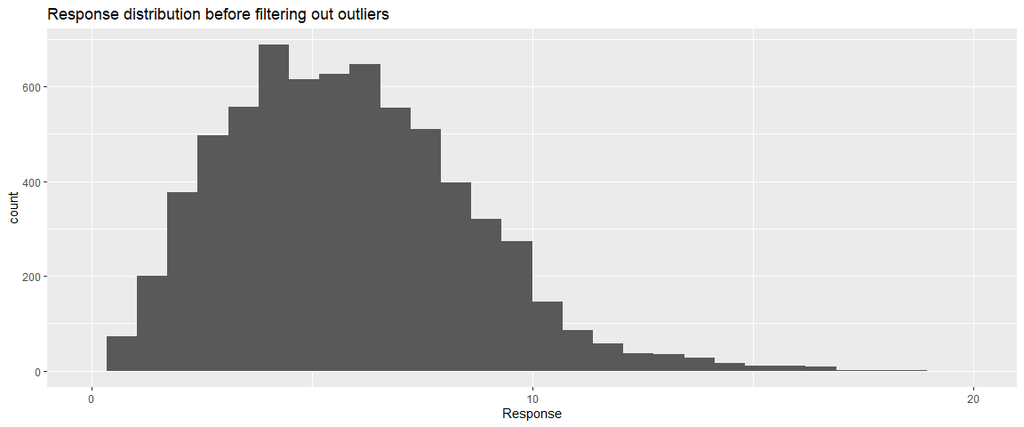

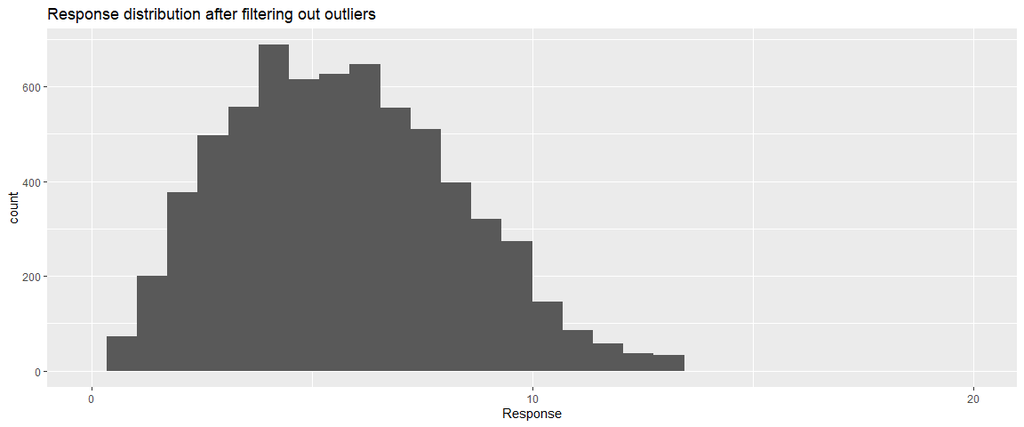

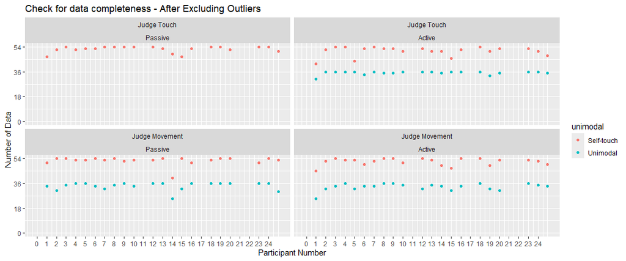

# 2 Research questions

## 2.1 Self-touch: Interhemispheric interference

### 2.1.1 Basic analyses

- **Judgement Error** quantifies *perceptual interference* with both positive and negative value, i.e., overestimation and negative estimation, respectively.

$$Judgement Error = \frac{reported
length}{true length}\ - 1$$

- **ABSOLUTE Judgement Error** quantifies *perceptual interference* without negative value, i.e., the degree to which the perceptual judgement deviates from the true value OR how much the perceptual judgement is interfered by other information.

$$ABSOLUTE Judgement Error =
|JudgementError| = |\frac{reported length}{true length}\ -
1|$$

- **Beta Power Difference** between the left hemisphere (C3) and the right hemisphere (C4) represents the degree to which motor activity interferes with tactile processing. Positive difference implies weaker interference of motor information (tactile focus), while negative difference implies stronger interference of motor information (motor focus).

$$\Delta{B} = B_{C3} - B_{C4}$$

Because movement and tactile spatial percepts during self-touch are interfered by the processing of tactile and movement information, respectively, we expect that the neural marker of these two components could be used to predict judgement accuracy. For example, a negative difference in beta power between C3 and C4 *(C3 - C4)* reflects larger processing of motor information relative to tactile information and may suggest that motor information is weighted more in length judgement than tactile judgement

**Q6: (Self-touch conditions) Does the relative difference in beta power between channel C3 and C4 during self-touch explain the asymmetrical, bidirectional interference of movement and tactile spatial percepts?**

H6: Negative difference in the beta power between the channels C3 and C4 [C3-C4] (i.e., stronger motor processing than tactile processing) is associated with smaller error in move judgement and smaller tactile judgement.

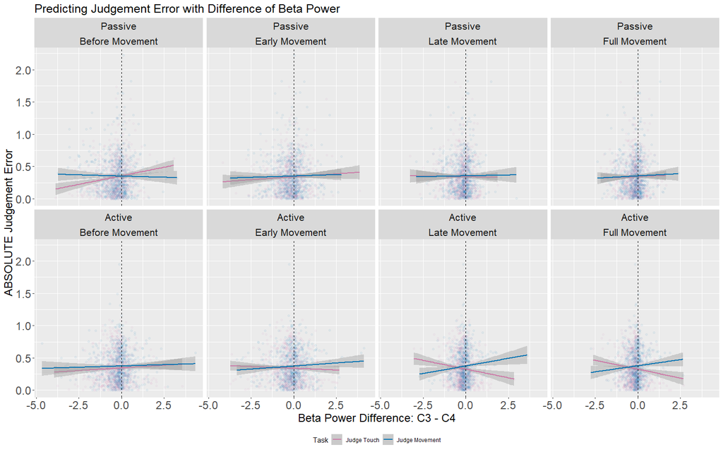

```
## Linear mixed model fit by REML. t-tests use Satterthwaite's method [
## lmerModLmerTest]
## Formula: absError ~ PowerDiff * task * mov + (1 | sbjN)
##    Data: predictData
##
## REML criterion at convergence: 190.4
##
## Scaled residuals:
##     Min      1Q  Median      3Q     Max
## -2.5143 -0.7074 -0.1457  0.5591  6.5005
##
## Random effects:
##  Groups   Name        Variance Std.Dev.
##  sbjN     (Intercept) 0.01182  0.1087
##  Residual             0.06027  0.2455
## Number of obs: 2717, groups:  sbjN, 21
##
## Fixed effects:
##                                          Estimate Std. Error         df t value
## (Intercept)                               0.34491    0.02600   26.62610  13.267
## PowerDiff                                 0.01534    0.01846 2702.59708   0.831
## taskJudge Movement                        0.01058    0.01457 2690.43512   0.726
## movActive                                -0.01385    0.01469 2691.11134  -0.943
## PowerDiff:taskJudge Movement             -0.01513    0.02548 2698.06718  -0.594
## PowerDiff:movActive                      -0.04923    0.02529 2697.23367  -1.947
## taskJudge Movement:movActive              0.03669    0.02019 2690.02129   1.817
## PowerDiff:taskJudge Movement:movActive    0.07313    0.03649 2697.63249   2.004
##                                        Pr(>|t|)
## (Intercept)                            3.02e-13 ***
## PowerDiff                                0.4062
## taskJudge Movement                       0.4676
## movActive                                0.3459
## PowerDiff:taskJudge Movement             0.5525
## PowerDiff:movActive                      0.0517 .
## taskJudge Movement:movActive             0.0693 .
## PowerDiff:taskJudge Movement:movActive   0.0451 *
## ---
## Signif. codes:  0 '***' 0.001 '**' 0.01 '*' 0.05 '.' 0.1 ' ' 1
##
## Correlation of Fixed Effects:
##             (Intr) PwrDff tskJdM mvActv PwD:JM PwrD:A tsJM:A
## PowerDiff    0.180
## tskJdgMvmnt -0.294 -0.308
## movActive   -0.293 -0.304  0.518
## PwrDff:tsJM -0.124 -0.696  0.385  0.214
## PwrDff:mvAc -0.126 -0.702  0.220  0.410  0.497
## tskJMvmnt:A  0.210  0.212 -0.719 -0.724 -0.275 -0.293
## PwrDff:JM:A  0.082  0.467 -0.264 -0.279 -0.691 -0.685  0.345
```

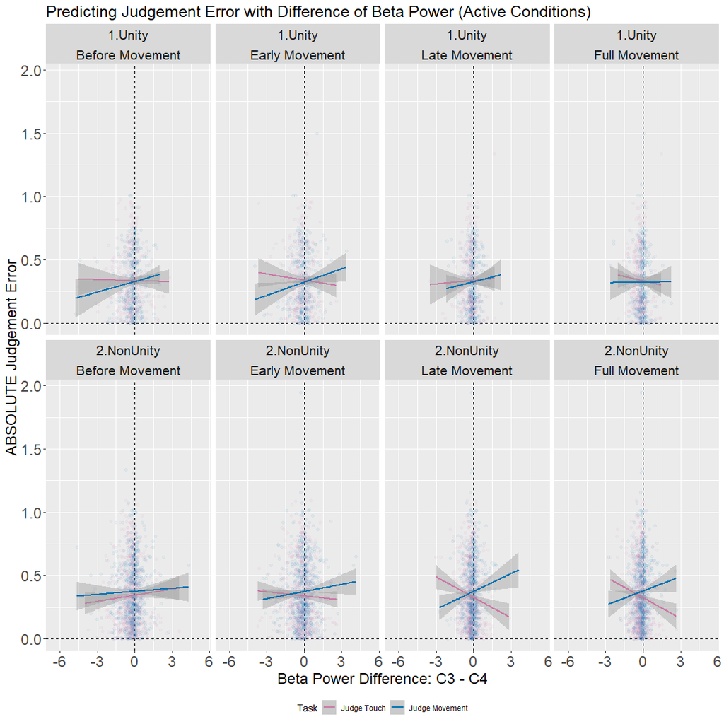

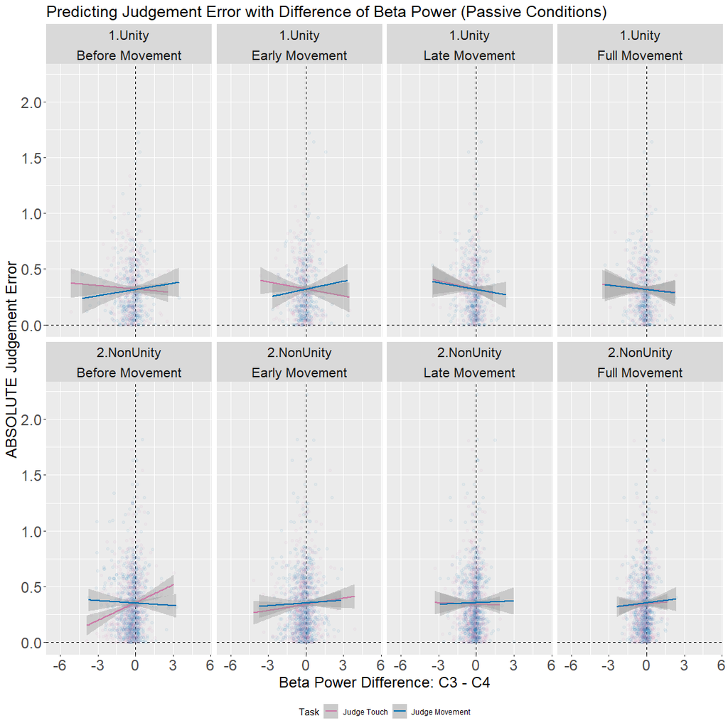

```
## Linear mixed model fit by REML. t-tests use Satterthwaite's method [
## lmerModLmerTest]
## Formula: absError ~ PowerDiff * task * mov * gain + (1 | sbjN)
##    Data: predictData
##
## REML criterion at convergence: -54.7
##
## Scaled residuals:
##     Min      1Q  Median      3Q     Max
## -2.7051 -0.6959 -0.1412  0.5517  6.6971
##
## Random effects:
##  Groups   Name        Variance Std.Dev.
##  sbjN     (Intercept) 0.01348  0.1161
##  Residual             0.05546  0.2355
## Number of obs: 4081, groups:  sbjN, 21
##
## Fixed effects:
##                                                         Estimate Std. Error
## (Intercept)                                            3.163e-01  2.897e-02
## PowerDiff                                             -2.167e-02  2.044e-02
## taskJudge Movement                                     4.822e-03  1.949e-02
## movActive                                              1.865e-02  2.007e-02
## gain2.NonUnity                                         2.906e-02  1.725e-02
## PowerDiff:taskJudge Movement                           1.433e-02  2.925e-02
## PowerDiff:movActive                                    9.408e-03  3.327e-02
## taskJudge Movement:movActive                          -1.664e-02  2.743e-02
## PowerDiff:gain2.NonUnity                               3.882e-02  2.650e-02
## taskJudge Movement:gain2.NonUnity                      4.546e-03  2.394e-02
## movActive:gain2.NonUnity                              -3.196e-02  2.447e-02
## PowerDiff:taskJudge Movement:movActive                -1.165e-02  4.773e-02
## PowerDiff:taskJudge Movement:gain2.NonUnity           -3.857e-02  3.763e-02
## PowerDiff:movActive:gain2.NonUnity                    -5.573e-02  4.081e-02
## taskJudge Movement:movActive:gain2.NonUnity            5.377e-02  3.354e-02
## PowerDiff:taskJudge Movement:movActive:gain2.NonUnity  8.753e-02  5.880e-02
##                                                               df t value
## (Intercept)                                            3.271e+01  10.919
## PowerDiff                                              4.049e+03  -1.060
## taskJudge Movement                                     4.046e+03   0.247
## movActive                                              4.045e+03   0.929
```

[output cut: 16 more lines]

```
## movActive                                               0.3528
## gain2.NonUnity                                          0.0922 .
## PowerDiff:taskJudge Movement                            0.6243
## PowerDiff:movActive                                     0.7774
## taskJudge Movement:movActive                            0.5440
## PowerDiff:gain2.NonUnity                                0.1431
## taskJudge Movement:gain2.NonUnity                       0.8494
## movActive:gain2.NonUnity                                0.1917
## PowerDiff:taskJudge Movement:movActive                  0.8072
## PowerDiff:taskJudge Movement:gain2.NonUnity             0.3055
## PowerDiff:movActive:gain2.NonUnity                      0.1722
## taskJudge Movement:movActive:gain2.NonUnity             0.1090
## PowerDiff:taskJudge Movement:movActive:gain2.NonUnity   0.1366
## ---
## Signif. codes:  0 '***' 0.001 '**' 0.01 '*' 0.05 '.' 0.1 ' ' 1
```

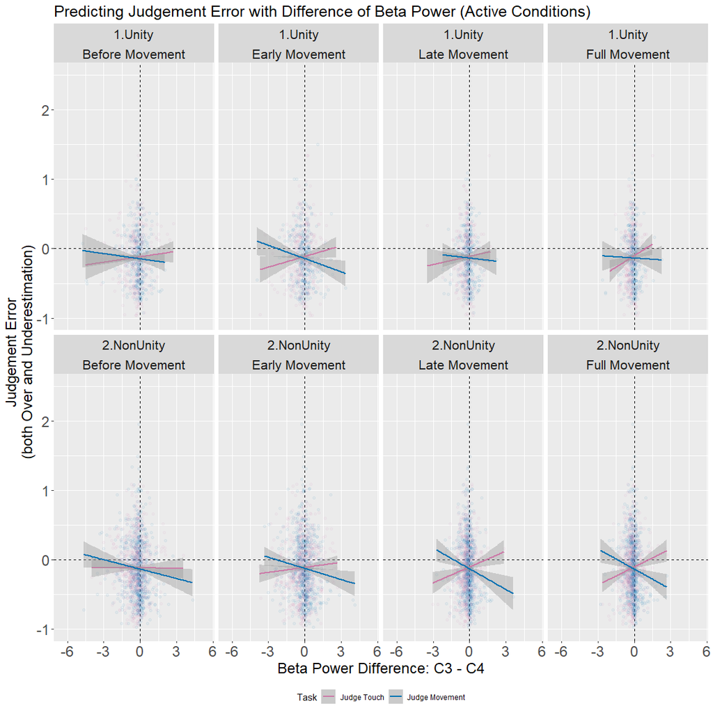

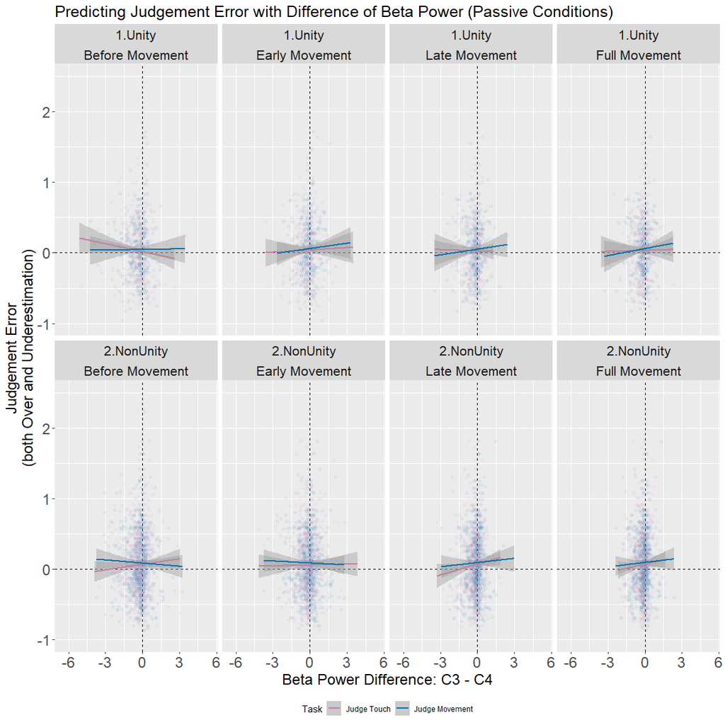

```
## Linear mixed model fit by REML. t-tests use Satterthwaite's method [
## lmerModLmerTest]
## Formula: estError ~ PowerDiff * task * mov * gain + (1 | sbjN)
##    Data: predictData
##
## REML criterion at convergence: 1974.9
##
## Scaled residuals:
##     Min      1Q  Median      3Q     Max
## -4.9175 -0.6592 -0.0938  0.5638  5.0286
##
## Random effects:
##  Groups   Name        Variance Std.Dev.
##  sbjN     (Intercept) 0.09049  0.3008
##  Residual             0.09074  0.3012
## Number of obs: 4081, groups:  sbjN, 21
##
## Fixed effects:
##                                                         Estimate Std. Error
## (Intercept)                                              0.03170    0.06806
## PowerDiff                                                0.00512    0.02615
## taskJudge Movement                                       0.02065    0.02493
## movActive                                               -0.16256    0.02567
## gain2.NonUnity                                           0.02762    0.02207
## PowerDiff:taskJudge Movement                             0.01014    0.03742
## PowerDiff:movActive                                      0.02555    0.04257
## taskJudge Movement:movActive                            -0.02419    0.03508
## PowerDiff:gain2.NonUnity                                 0.01539    0.03390
## taskJudge Movement:gain2.NonUnity                        0.01223    0.03062
## movActive:gain2.NonUnity                                -0.01864    0.03131
## PowerDiff:taskJudge Movement:movActive                   0.01459    0.06106
## PowerDiff:taskJudge Movement:gain2.NonUnity              0.01762    0.04813
## PowerDiff:movActive:gain2.NonUnity                      -0.02981    0.05220
## taskJudge Movement:movActive:gain2.NonUnity             -0.01868    0.04291
## PowerDiff:taskJudge Movement:movActive:gain2.NonUnity   -0.08341    0.07522
##                                                               df t value
## (Intercept)                                             22.85814   0.466
## PowerDiff                                             4046.09580   0.196
## taskJudge Movement                                    4045.12372   0.828
## movActive                                             4045.09799  -6.333
```

[output cut: 16 more lines]

```
## movActive                                             2.67e-10 ***
## gain2.NonUnity                                           0.211
## PowerDiff:taskJudge Movement                             0.786
## PowerDiff:movActive                                      0.548
## taskJudge Movement:movActive                             0.491
## PowerDiff:gain2.NonUnity                                 0.650
## taskJudge Movement:gain2.NonUnity                        0.690
## movActive:gain2.NonUnity                                 0.552
## PowerDiff:taskJudge Movement:movActive                   0.811
## PowerDiff:taskJudge Movement:gain2.NonUnity              0.714
## PowerDiff:movActive:gain2.NonUnity                       0.568
## taskJudge Movement:movActive:gain2.NonUnity              0.663
## PowerDiff:taskJudge Movement:movActive:gain2.NonUnity    0.268
## ---
## Signif. codes:  0 '***' 0.001 '**' 0.01 '*' 0.05 '.' 0.1 ' ' 1
```

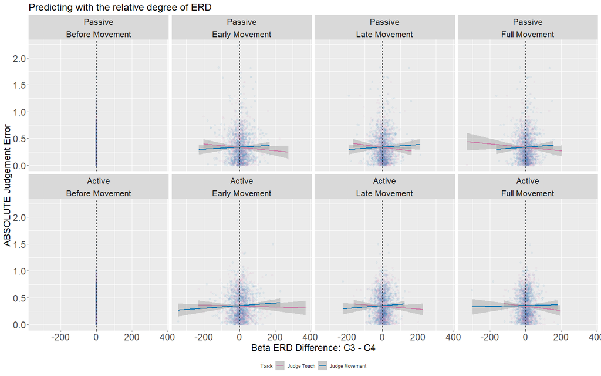

```
## Linear mixed model fit by REML. t-tests use Satterthwaite's method [
## lmerModLmerTest]
## Formula: absError ~ PowerDiff * task * mov + (1 | sbjN)
##    Data: predictData
##
## REML criterion at convergence: -48
##
## Scaled residuals:
##     Min      1Q  Median      3Q     Max
## -2.7472 -0.6903 -0.1523  0.5570  6.7524
##
## Random effects:
##  Groups   Name        Variance Std.Dev.
##  sbjN     (Intercept) 0.01357  0.1165
##  Residual             0.05551  0.2356
## Number of obs: 3903, groups:  sbjN, 21
##
## Fixed effects:
##                                          Estimate Std. Error         df t value
## (Intercept)                             3.335e-01  2.658e-02  2.284e+01  12.549
## PowerDiff                              -2.219e-04  2.292e-04  3.877e+03  -0.969
## taskJudge Movement                      1.005e-02  1.083e-02  3.875e+03   0.927
## movActive                               5.391e-03  1.080e-02  3.876e+03   0.499
## PowerDiff:taskJudge Movement            4.666e-04  3.121e-04  3.876e+03   1.495
## PowerDiff:movActive                     5.060e-05  3.335e-04  3.876e+03   0.152
## taskJudge Movement:movActive            6.114e-03  1.515e-02  3.875e+03   0.404
## PowerDiff:taskJudge Movement:movActive -1.974e-04  4.569e-04  3.876e+03  -0.432
##                                        Pr(>|t|)
## (Intercept)                            9.93e-12 ***
## PowerDiff                                 0.333
## taskJudge Movement                        0.354
## movActive                                 0.618
## PowerDiff:taskJudge Movement              0.135
## PowerDiff:movActive                       0.879
## taskJudge Movement:movActive              0.687
## PowerDiff:taskJudge Movement:movActive    0.666
## ---
## Signif. codes:  0 '***' 0.001 '**' 0.01 '*' 0.05 '.' 0.1 ' ' 1
##
## Correlation of Fixed Effects:
##             (Intr) PwrDff tskJdM mvActv PwD:JM PwrD:A tsJM:A
## PowerDiff   -0.023
## tskJdgMvmnt -0.206  0.055
## movActive   -0.208  0.055  0.507
## PwrDff:tsJM  0.017 -0.731 -0.087 -0.041
## PwrDff:mvAc  0.016 -0.682 -0.037 -0.083  0.501
## tskJMvmnt:A  0.147 -0.039 -0.714 -0.711  0.062  0.059
## PwrDff:JM:A -0.012  0.497  0.059  0.060 -0.682 -0.729 -0.084
```

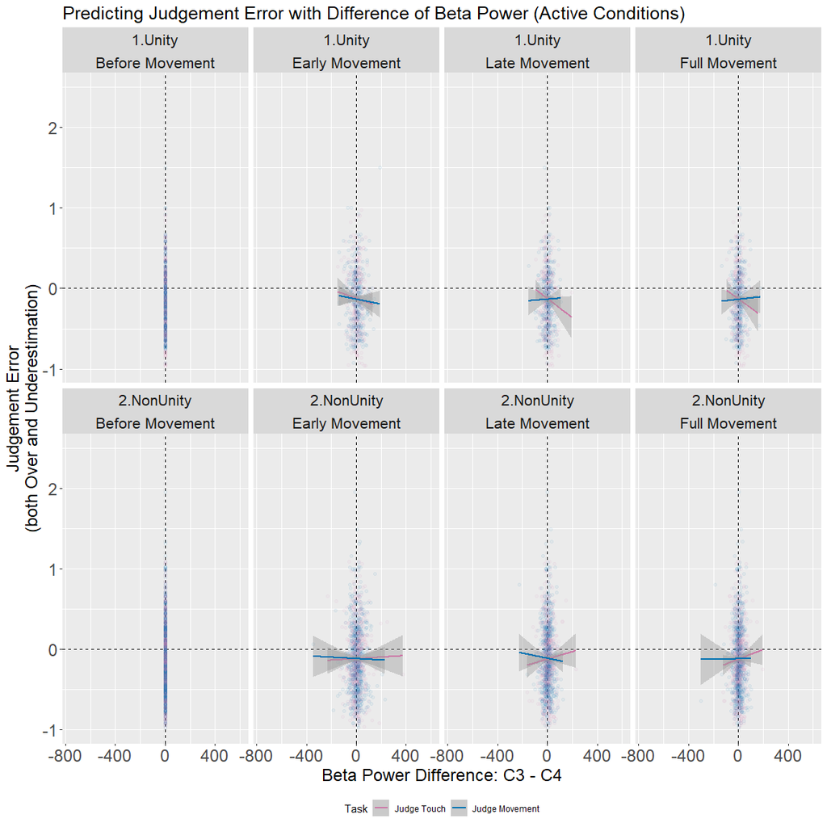

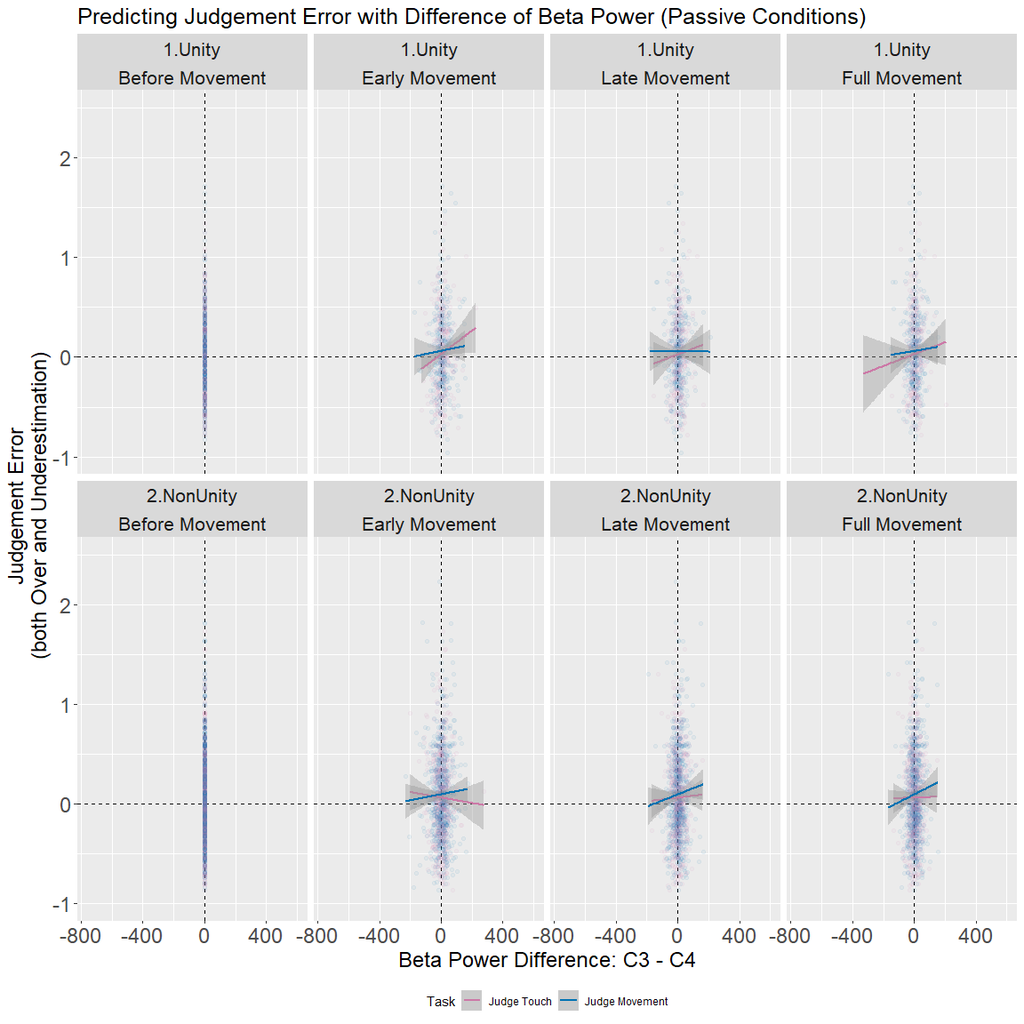

[output not shown]

[output cut: 16 more lines]

[output not shown]

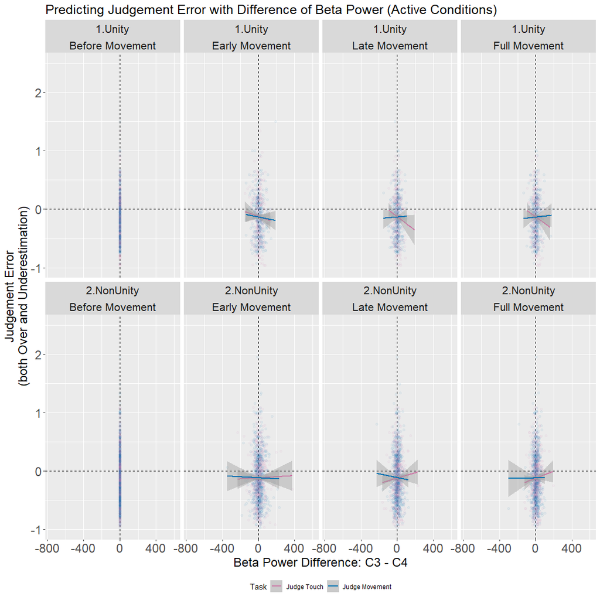

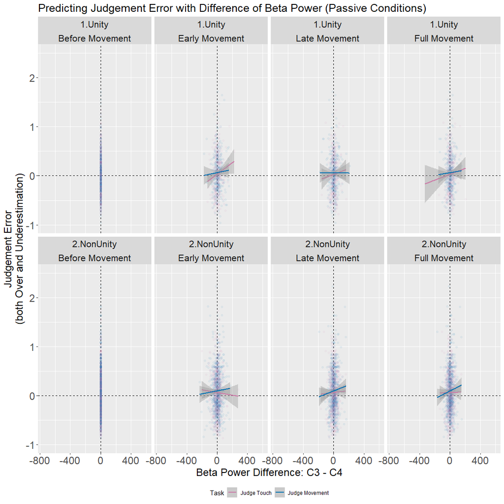

[output not shown]

[output cut: 16 more lines]

[output not shown]